# Random Forest

# Tarea 5.

# Metodos supervisados

Librerias

```r
library(caTools)
library(rpart)
library(randomForest)
```

```r
library(corrplot)
library(dplyr)
library(ggplot2)
library(rpart.plot)
library(randomForest)
```

**1.** Desarolle el Análisis del Problema

Un modelo de clasficacion de hongos comestibles o venesos, podría ser de gran utilidad para ayudar a estudiar nuevas especies de hongos o incluso ayudar a personas a saber si es seguro comer algún hongo en cuestión. Es ahí donde el data set de agaricus lepiota nos puede ayudar aplicando distintos modelos.

Fuente del dataset: https://archive.ics.uci.edu/ml/machine-learning-databases/mushroom/agaricus-lepiota.data

**1.** Cargue el archivo agaricus_lepiota.data.csv en una variable

```r
mushroom<- read.csv(file = "datos/agaricus-lepiota.data", header = FALSE, sep = ",",strip.white = TRUE,
                    stringsAsFactors = TRUE,
                    col.names = c("class","cap-shape","cap-surface","cap-color","bruises",
                                  "odor","gill-attachment","gill-spacing","gill-size",
                                  "gill-color","stalk-shape","stalk-root","stalk-surface-above-ring",
                                  "stalk-surface-below-ring","stalk-color-above-ring","stalk-color-below-ring",
                                  "veil-type","veil-color","ring-number","ring-type","spore-print-color",
                                  "population","habitat"))
# Calcular numero de niveles por cada variable
mushroom.levels <- cbind.data.frame(
  Variable=names(mushroom),
  Total_Levels=sapply(mushroom, function(x) {
    as.numeric(length(levels(x)))
  }))
print(mushroom.levels)
```

```
##                                          Variable Total_Levels
## class                                       class            2
## cap.shape                               cap.shape            6
## cap.surface                           cap.surface            4
## cap.color                               cap.color           10
## bruises                                   bruises            2
## odor                                         odor            9
## gill.attachment                   gill.attachment            2
## gill.spacing                         gill.spacing            2
## gill.size                               gill.size            2
## gill.color                             gill.color           12
## stalk.shape                           stalk.shape            2
## stalk.root                             stalk.root            5
## stalk.surface.above.ring stalk.surface.above.ring            4
## stalk.surface.below.ring stalk.surface.below.ring            4
## stalk.color.above.ring     stalk.color.above.ring            9
## stalk.color.below.ring     stalk.color.below.ring            9
## veil.type                               veil.type            1
## veil.color                             veil.color            4
## ring.number                           ring.number            3
## ring.type                               ring.type            5
## spore.print.color               spore.print.color            9
## population                             population            6
## habitat                                   habitat            7
```

```r
# Cambiamos niveles de cada variable por nombres más significativos y entendibles
levels(mushroom$class)<- c("edible","poisonous")
levels(mushroom$cap.shape)<-c("bell","conical","flat","knobbed","sunken","convex")
levels(mushroom$cap.surface)<- c("fibrous","grooves","smooth","scaly")
levels(mushroom$cap.color)<- c("buff","cinnamon","red","gray","brown","pink","green","purple","white","yellow")
levels(mushroom$bruises)<- c("bruisesno","bruisesyes")
levels(mushroom$odor)<-c("almond","creosote","foul","anise","musty","nosmell","pungent","spicy","fishy")
levels(mushroom$gill.attachment)<- c("attached","free")
levels(mushroom$gill.spacing)<- c("close","crowded")
levels(mushroom$gill.size)<-c("broad","narrow")
levels(mushroom$gill.color)<- c("buff","red","gray","chocolate","black","brown","orange","pink","green","purple","white","yellow")
levels(mushroom$stalk.shape)<- c("enlarging","tapering")
levels(mushroom$stalk.root)<- c("missing","bulbous","club","equal","rooted")
levels(mushroom$stalk.surface.above.ring)<-c("fibrous","silky","smooth","scaly")
levels(mushroom$stalk.surface.below.ring)<-c("fibrous","silky","smooth","scaly")
levels(mushroom$stalk.color.above.ring)<- c("buff","cinnamon","red","gray","brown", "orange","pink","white","yellow")
levels(mushroom$stalk.color.below.ring)<- c("buff","cinnamon","red","gray","brown", "orange","pink","white","yellow")
levels(mushroom$veil.type)<-c("partial")
levels(mushroom$veil.color)<- c("brown","orange","white","yellow")
levels(mushroom$ring.number)<-c("none","one","two")
levels(mushroom$ring.type)<- c("evanescent","flaring","large","none","pendant")
levels(mushroom$spore.print.color)<- c("buff","chocolate","black","brown","orange","green","purple","white","yellow")
levels(mushroom$population)<- c("abundant","clustered","numerous","scattered","several","solitary")
levels(mushroom$habitat)<-c("woods","grasses","leaves","meadows","paths","urban","waste")
```

**2.** Desarolle el Entendimiento de los Datos

1. cap-shape: bell=b,conical=c,convex=x,flat=f,knobbed=k,sunken=s
2. cap-surface: fibrous=f,grooves=g,scaly=y,smooth=s
3. cap-color: brown=n,buff=b,cinnamon=c,gray=g,green=r,pink=p,purple=u,red=e,white=w,yellow=y
4. bruises?: bruises=t,no=f
5. odor: almond=a,anise=l,creosote=c,fishy=y,foul=f,musty=m,none=n,pungent=p,spicy=s
6. gill-attachment: attached=a,descending=d,free=f,notched=n
7. gill-spacing: close=c,crowded=w,distant=d
8. gill-size: broad=b,narrow=n
9. gill-color: black=k,brown=n,buff=b,chocolate=h,gray=g,green=r,orange=o,pink=p,purple=u,red=e,white=w,yellow=y
10. stalk-shape: enlarging=e,tapering=t
11. stalk-root: bulbous=b,club=c,cup=u,equal=e,rhizomorphs=z,rooted=r,missing=?
12. stalk-surface-above-ring:fibrous=f,scaly=y,silky=k,smooth=s
13. stalk-surface-below-ring:fibrous=f,scaly=y,silky=k,smooth=s
14. stalk-color-above-ring: brown=n,buff=b,cinnamon=c,gray=g,orange=o,pink=p,red=e,white=w,yellow=y
15. stalk-color-below-ring: brown=n,buff=b,cinnamon=c,gray=g,orange=o,pink=p,red=e,white=w,yellow=y
16. veil-type: partial=p,universal=u
17. veil-color: brown=n,orange=o,white=w,yellow=y
18. ring-number: none=n,one=o,two=t
19. ring-type: cobwebby=c,evanescent=e,flaring=f,large=l,none=n,pendant=p,sheathing=s,zone=z
20. spore-print-color: black=k,brown=n,buff=b,chocolate=h,green=r,orange=o,purple=u,white=w,yellow=y
21. population: abundant=a,clustered=c,numerous=n,scattered=s,several=v,solitary=y
22. habitat: grasses=g,leaves=l,meadows=m,paths=p,urban=u,waste=w,woods=d

**3.** Utilizando barplot cree un gráfico de los atributos del dataset, observe las correlaciones entre atributos

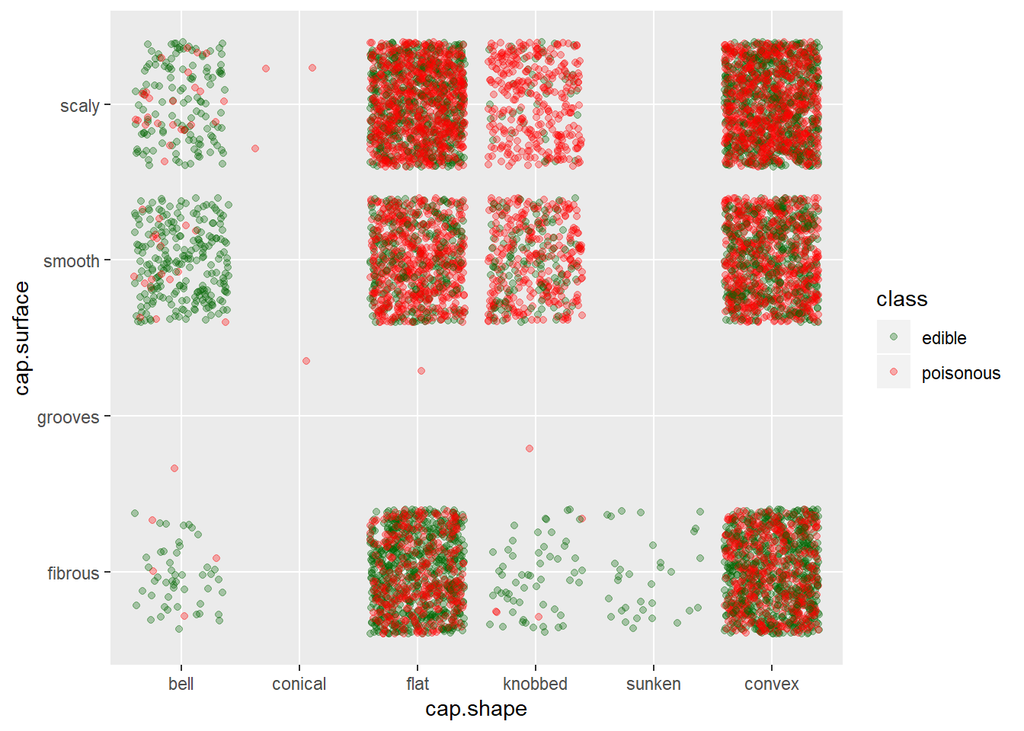

```r
ggplot(data = mushroom, aes(x=cap.shape, y=cap.surface, color=class)) +
  geom_jitter(alpha=0.3) +
    scale_color_manual(breaks = c('edible','poisonous'),values=c('darkgreen','red'))
```

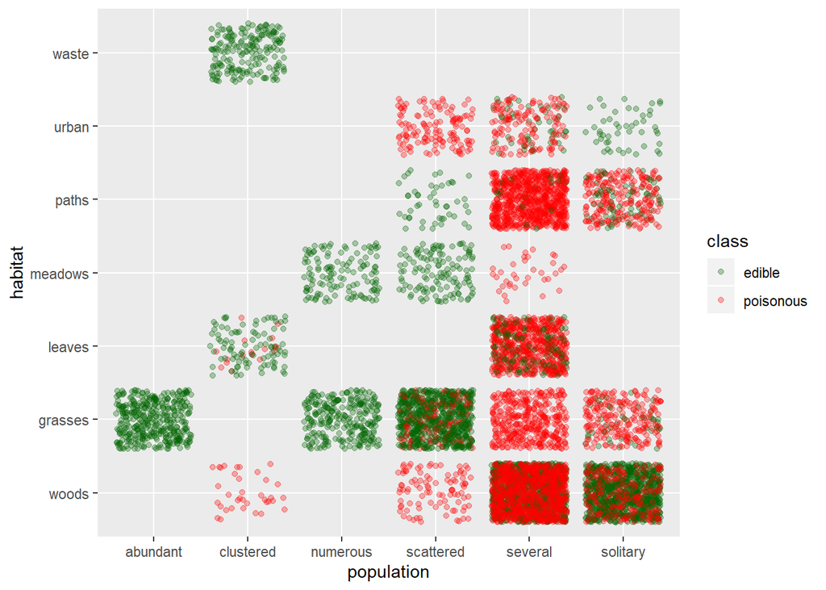

```r
ggplot(data = mushroom, aes(x=population, y=habitat, color=class)) +
  geom_jitter(alpha=0.3) +
    scale_color_manual(breaks = c('edible','poisonous'),values=c('darkgreen','red'))
```

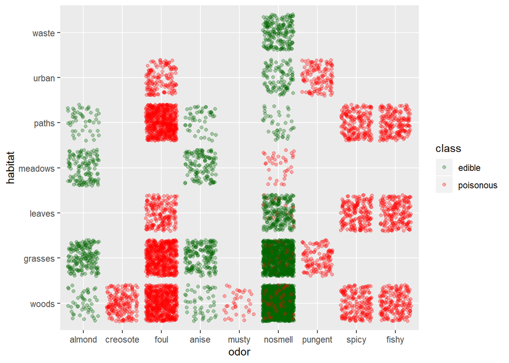

```r
ggplot(data = mushroom, aes(x=odor, y=habitat, color=class)) +
  geom_jitter(alpha=0.3) +
    scale_color_manual(breaks = c('edible','poisonous'),values=c('darkgreen','red'))
```

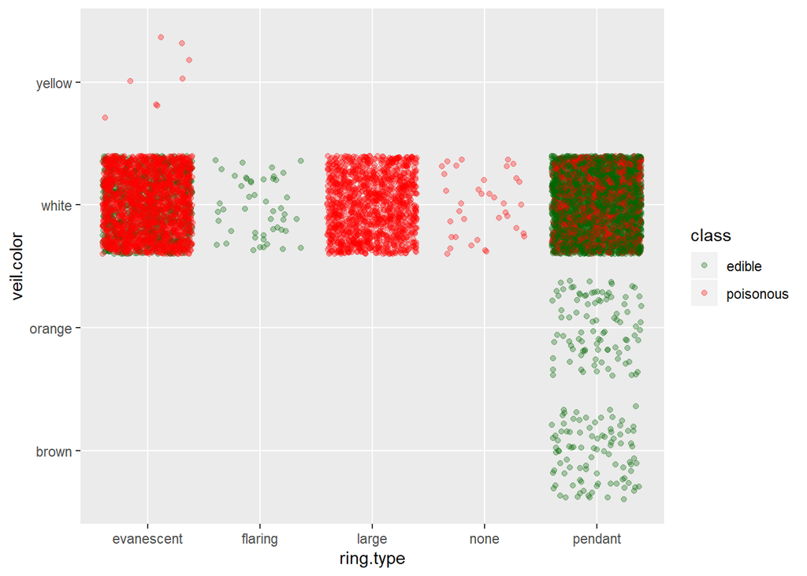

```r
ggplot(data = mushroom, aes(x=ring.type, y=veil.color, color=class)) +
  geom_jitter(alpha=0.3) +
    scale_color_manual(breaks = c('edible','poisonous'),values=c('darkgreen','red'))
```

> De la primer grafica podemos deducir que los hongos de con cap-shape sunken y cap.surface fibrous son comestibles, aunque hay pocos datos sobre este tipo de hongos.

> De la segunda podemos deducir los hongos de poblacion “abundant” y que habitan en “grasses” son comestibles, asi como los hongos “clustered” y que habitan en “waste”.

> La tercer grafica nos da el indicio de que los hongos con olor “almond” son comestibles independientemente de su habitad. Y los de olor “foul” tienden a ser venenosos independientemente de su habitad.

> Por ultimo la cuarta grafica nos muestra que los hongos con ring.type “large” y de veil.color “white” son venesos.

**4.** Realice al menos 3 modelos vistos en clase

```r
# Crear los sets de entrenamiento y prueba
set.seed(7)
splt <- sample.split(mushroom$class, SplitRatio = 0.7)
mushroom.entrenamiento <- mushroom[splt,]
mushroom.prueba <- mushroom[!splt,]
```

```r
modelo.arbol <- rpart(class ~ ., data = mushroom.entrenamiento, method =  'class')
modelo.bosque <- randomForest(class ~ ., data = mushroom.entrenamiento)
modelo.regresion <- glm(class ~ odor + cap.shape + ring.type + bruises + ring.number + gill.spacing, data = mushroom.entrenamiento, family = binomial)
```

**5.** Evaluación del modelo

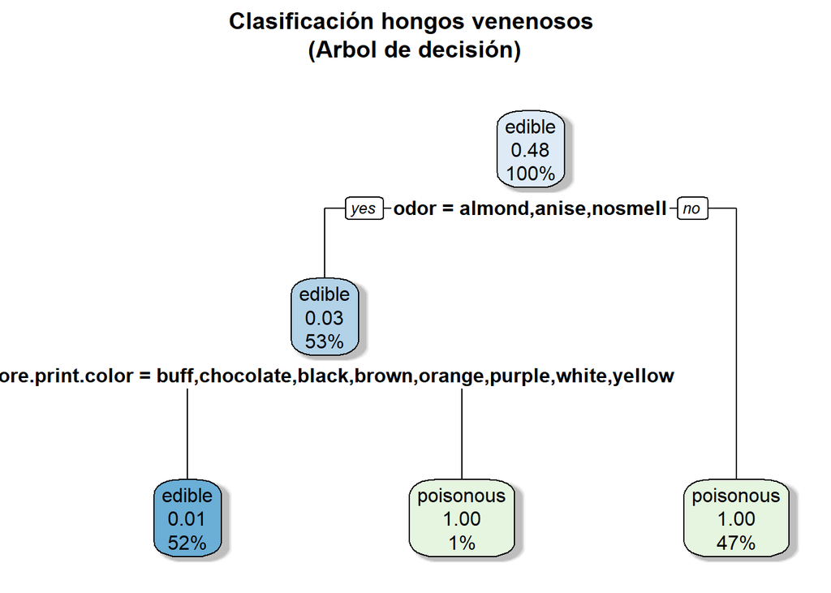

```r
rpart.plot(modelo.arbol,
           shadow.col = "gray",
           main = "Clasificación hongos venenosos \n(Arbol de decisión)\n")
```

```r
# Evaluamos las predicciones del arbol de decision
modelo.arbol.predicciones <- predict(modelo.arbol, newdata = mushroom.prueba, type = 'class')
modelo.arbol.evaluacion <- table(mushroom.prueba$class, modelo.arbol.predicciones)
print(modelo.arbol.evaluacion)
```

```
##            modelo.arbol.predicciones
##             edible poisonous
##   edible      1262         0
##   poisonous      9      1166
```

```r
# Evaluamos las predicciones del random forest
modelo.bosque.predicciones <- predict(modelo.bosque, newdata = mushroom.prueba, type = 'class')
modelo.bosque.evaluacion <- table(mushroom.prueba$class, modelo.bosque.predicciones)
print(modelo.bosque.evaluacion)
```

```
##            modelo.bosque.predicciones
##             edible poisonous
##   edible      1262         0
##   poisonous      0      1175
```

```r
# Evaluamos las predicciones de la regresion logistica
modelo.regresion.predicciones <- predict(modelo.regresion, newdata = mushroom.prueba, type = 'response')
modelo.regresion.evaluacion <- table(mushroom.prueba$class, modelo.regresion.predicciones)
print(modelo.bosque.evaluacion)
```

[output not shown]

```
##            modelo.bosque.predicciones
##             edible poisonous
##   edible      1262         0
##   poisonous      0      1175
```